# Group - 107

# Assignment 1- SET 3

```
 Course : Machine Learning
 Code : S1-22_AIMLCZG565
```

Group Members: Email Ids

1. Ganesh Mukesh Joshi 2022AA05218@wilp.bits-pilani.ac.in
2. Prajwal Gangawane 2022AA05220@wilp.bits-pilani.ac.in
3. Kinjal Joshi 2022AA05230@wilp.bits-pilani.ac.in

**Data Visualization and Exploration**

Reading data set from the given location.Following Columns are present in the data set # url="https://archive.ics.uci.edu/ml/machine-learning-databases/00291/airfoil_self_noise.dat"

**This problem has the following inputs:**

1. Frequency, in Hertzs.
2. Angle of attack, in degrees.
3. Chord length, in meters.
4. Free-stream velocity, in meters per second.
5. Suction side displacement thickness, in meters.

**Output is:**

1. Scaled sound pressure level, in decibels.

```python
#Import Libraries/Dataset
import numpy as np
import pandas as pd
import seaborn as sns
import matplotlib.pyplot as plt
import sklearn
import warnings

#supressing warnings
warnings.filterwarnings('ignore')

#reading data set from the given location

df_columns = ['frequency_hertz','angle_attack_degree','chord_length_meters','stream_velocity_mps','suction_disp_meters','scaled_sound_press_db']
url="https://archive.ics.uci.edu/ml/machine-learning-databases/00291/airfoil_self_noise.dat"
df_self_noise=pd.read_csv(url,
                          names= df_columns,
                          sep='\t')
```

**1.1 Print 2 rows for sanity check to identify all the features present in the dataset and if the target matches with them.**

```python
#1. Print 2 rows for sanity check to identify all the features present in the dataset and
#if the target matches with them.
df_self_noise.head(2)
```

|  | frequency_hertz | angle_attack_degree | chord_length_meters | stream_velocity_mps | suction_disp_meters | scaled_sound_press_db |
| --- | --- | --- | --- | --- | --- | --- |
| 0 | 800 | 0.0 | 0.3048 | 71.3 | 0.002663 | 126.201 |
| 1 | 1000 | 0.0 | 0.3048 | 71.3 | 0.002663 | 125.201 |

```python
#information about dataset
df_self_noise.info()
```

```
<class 'pandas.core.frame.DataFrame'>
RangeIndex: 1503 entries, 0 to 1502
Data columns (total 6 columns):
 #   Column                 Non-Null Count  Dtype
---  ------                 --------------  -----
 0   frequency_hertz        1503 non-null   int64
 1   angle_attack_degree    1503 non-null   float64
 2   chord_length_meters    1503 non-null   float64
 3   stream_velocity_mps    1503 non-null   float64
 4   suction_disp_meters    1503 non-null   float64
 5   scaled_sound_press_db  1503 non-null   float64
dtypes: float64(5), int64(1)
memory usage: 70.6 KB
```

```python
#information about dataset
df_self_noise.describe()
```

|  | frequency_hertz | angle_attack_degree | chord_length_meters | stream_velocity_mps | suction_disp_meters | scaled_sound_press_db |
| --- | --- | --- | --- | --- | --- | --- |
| count | 1503.000000 | 1503.000000 | 1503.000000 | 1503.000000 | 1503.000000 | 1503.000000 |
| mean | 2886.380572 | 6.782302 | 0.136548 | 50.860745 | 0.011140 | 124.835943 |
| std | 3152.573137 | 5.918128 | 0.093541 | 15.572784 | 0.013150 | 6.898657 |
| min | 200.000000 | 0.000000 | 0.025400 | 31.700000 | 0.000401 | 103.380000 |
| 25% | 800.000000 | 2.000000 | 0.050800 | 39.600000 | 0.002535 | 120.191000 |
| 50% | 1600.000000 | 5.400000 | 0.101600 | 39.600000 | 0.004957 | 125.721000 |
| 75% | 4000.000000 | 9.900000 | 0.228600 | 71.300000 | 0.015576 | 129.995500 |
| max | 20000.000000 | 22.200000 | 0.304800 | 71.300000 | 0.058411 | 140.987000 |

**1.2 Comment on class imbalance with appropriate visualization method.**

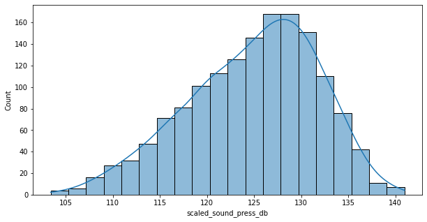

```python
#2. Comment on class imbalance with appropriate visualization method.
#Target column -> scaled_sound_press_db
fig, axis = plt.subplots(1,figsize=(10,5))
sns.histplot(data=df_self_noise, x='scaled_sound_press_db',bins=20, kde=True)
```

Target column scaled_sound_press_db is skewed, skewness point to the presence of outliers.

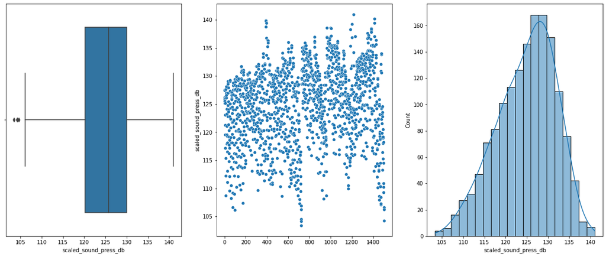

```python
fig, axis = plt.subplots(1,3,figsize=(20,8))
sns.boxplot(x=df_self_noise.scaled_sound_press_db,ax=axis[0])
sns.scatterplot(data=df_self_noise.scaled_sound_press_db,ax=axis[1])
sns.histplot(data=df_self_noise, x='scaled_sound_press_db',bins=20, kde=True,ax=axis[2])
```

**1.2 Comment on class imbalance with appropriate visualization method**

Target column **scaled_sound_press_db** is skewed.

1. Skewness point to the presence of outliers.
2. Min value of the target column is 103.38 and maximum value is 140.987.
3. Majority of the values are between 120 and 130 decibals.

**1.3 Provide appropriate visualizations to get an insight about the dataset**

```
frequency_hertz            21
angle_attack_degree        27
chord_length_meters         6
stream_velocity_mps         4
suction_disp_meters       105
scaled_sound_press_db    1456
dtype: int64
```

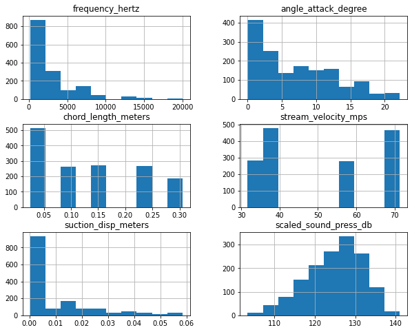

```python
#3. Provide appropriate visualizations to get an insight about the dataset.
df_self_noise.hist(figsize=(10,8))

print(df_self_noise.nunique(axis=0))
```

**Insight about dataset**

1. frequency_hertz, angle_attack_degree and suction_disp_meters data distribution is skewed.
2. chord_length_meters and stream_velocity_mps data distribution is sparce.
3. Target scaled_sound_press_db is skewed.
4. Skewness of data points to the presence of outliers in the data.

**From the data distinct values as under**

1. frequency_hertz - 21
2. angle_attack_degree - 27
3. chord_length_meters - 6
4. stream_velocity_mps - 4
5. suction_disp_meters - 105
6. scaled_sound_press_db - 1456

**1.4 Do the correlational analysis on the dataset Provide a visualization for the same. Will this correlational analysis have effect on feature selection that you will perform in the next step**

```python
#Do the correlational analysis on the dataset. Provide a visualization for the same.
#Will this correlational analysis have effect on feature selection that you will
#perform in the next step?
  # Creates correlation matrix
corr = df_self_noise.corr()
corr
```

|  | frequency_hertz | angle_attack_degree | chord_length_meters | stream_velocity_mps | suction_disp_meters | scaled_sound_press_db |
| --- | --- | --- | --- | --- | --- | --- |
| frequency_hertz | 1.000000 | -0.272765 | -0.003661 | 0.133664 | -0.230107 | -0.390711 |
| angle_attack_degree | -0.272765 | 1.000000 | -0.504868 | 0.058760 | 0.753394 | -0.156108 |
| chord_length_meters | -0.003661 | -0.504868 | 1.000000 | 0.003787 | -0.220842 | -0.236162 |
| stream_velocity_mps | 0.133664 | 0.058760 | 0.003787 | 1.000000 | -0.003974 | 0.125103 |
| suction_disp_meters | -0.230107 | 0.753394 | -0.220842 | -0.003974 | 1.000000 | -0.312670 |
| scaled_sound_press_db | -0.390711 | -0.156108 | -0.236162 | 0.125103 | -0.312670 | 1.000000 |

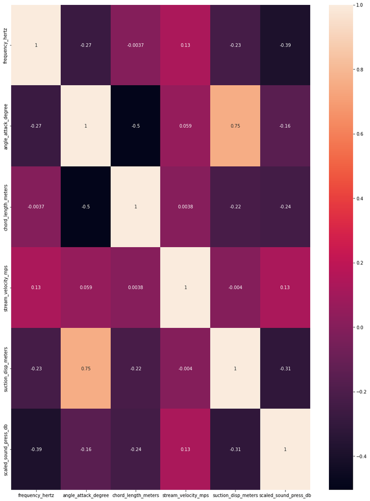

```python
plt.figure(figsize=(15,20))
sns.heatmap(data = corr,annot=True)
```

**angle_attack_degree and suction_disp_meters show high level of correlation of 0.75, even though the values show corelation, however the value set is sparce so choosing to retain both values.**

Distinct values for:

1. angle_attack_degree - 27
2. suction_disp_meters - 105

(We have checked that dropping angle_attack_degree reduces accuracy in the model so retaining both values)

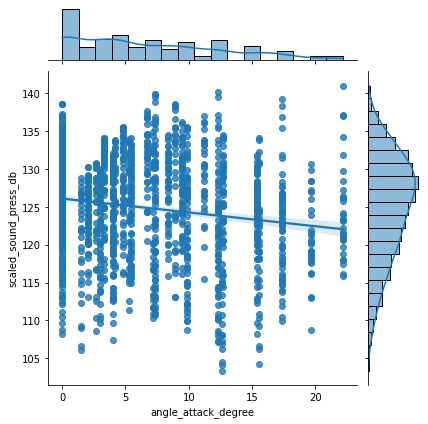

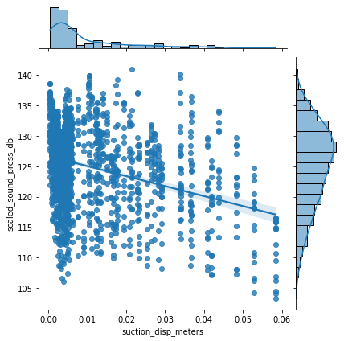

```python
#check joint plot for angle_attack_degree and suction_disp_meters with Scaled_sound_pressure
sns.jointplot(x='angle_attack_degree',y='scaled_sound_press_db',data=df_self_noise, kind='reg')
sns.jointplot(x='suction_disp_meters',y='scaled_sound_press_db',data=df_self_noise, kind='reg')
```

**2. Data Pre-processing and cleaning**

```python
#identifying null values in data
df_self_noise.isna().sum().sum()
```

```
0
```

No Missing or null values in the data set

**Data Normalization and Standarization** We can either :

1. Remove outlier using Inter-quartile range or z-score, however removing outlier will cause loss of data.
2. Capping outliers to mix and max value.
3. Replace outliers with mean/median and treat them as missing values.

Since most of the outlier values seem to lie on edges so we will choose to replace all high values where (mean + 3 *std) and low values where (mean - 3* std) with capped values. Tuning the calculation we find that capping values to (mean + 2 *std) and (mean - 2* std.) reduce the outliers

**We will leave out stream_velocity_mps from scaling as it has only 4 unique values.**

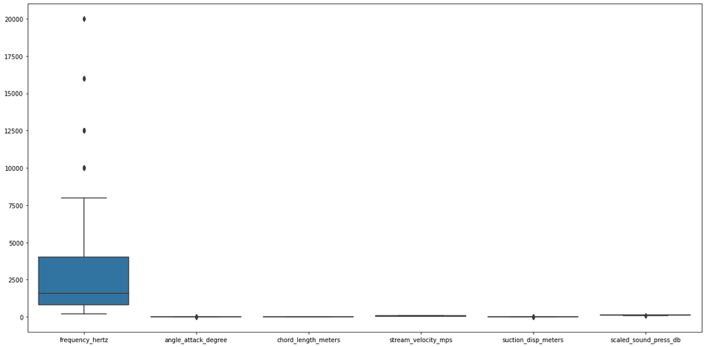

```python
#Checking outlier before cleanup
fig, axs = plt.subplots(1,figsize=(20,10))
sns.boxplot(data=df_self_noise,ax=axs)
```

```python
#replacing columns with capped upped and lower bounds
for column_name in df_self_noise.columns:
  replace_value = df_self_noise[column_name].mean()
  lower_limit = df_self_noise[column_name].mean() - 2 * df_self_noise[column_name].std()
  upper_limit = df_self_noise[column_name].mean() + 2 * df_self_noise[column_name].std()
  print(column_name,lower_limit, upper_limit)
  if column_name not in ['stream_velocity_mps']:
    df_self_noise[column_name] = np.where(df_self_noise[column_name] > upper_limit,upper_limit,
                               np.where(df_self_noise[column_name] < lower_limit,lower_limit,
                                        df_self_noise[column_name]))
```

```
frequency_hertz -3418.765701672382 9191.526846050292
angle_attack_degree -5.0539541872313665 18.618558312314534
chord_length_meters -0.050533219888318465 0.3236296936075467
stream_velocity_mps 19.715176385542666 82.00631396708543
suction_disp_meters -0.015160588142411986 0.037440348924847114
scaled_sound_press_db 111.03862953784702 138.63325602436194
```

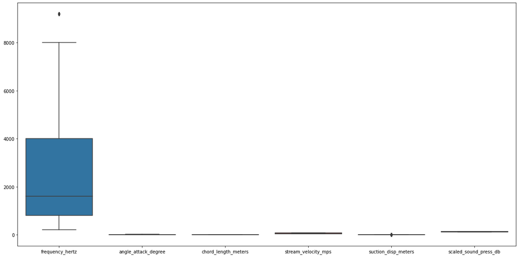

```python
#reviewing the outliers after capping values
fig, axs = plt.subplots(1,figsize=(20,10))
sns.boxplot(data=df_self_noise,ax=axs)
```

```
array([[<matplotlib.axes._subplots.AxesSubplot object at 0x7fde62b81e50>,
      dtype=object)
```

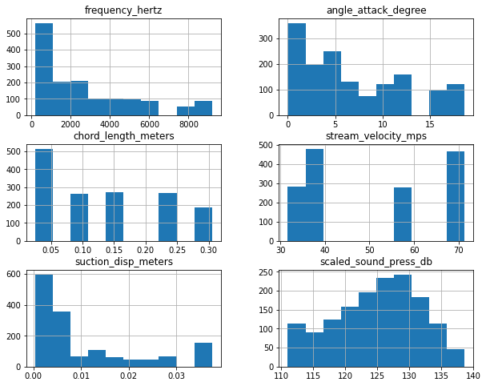

```python
df_self_noise.hist(figsize=(10,8))
```

```python
df_self_noise.describe()
```

|  | frequency_hertz | angle_attack_degree | chord_length_meters | stream_velocity_mps | suction_disp_meters | scaled_sound_press_db |
| --- | --- | --- | --- | --- | --- | --- |
| count | 1503.000000 | 1503.000000 | 1503.000000 | 1503.000000 | 1503.000000 | 1503.000000 |
| mean | 2706.720764 | 6.690670 | 0.136548 | 50.860745 | 0.010495 | 124.913361 |
| std | 2563.395873 | 5.706770 | 0.093541 | 15.572784 | 0.011375 | 6.693023 |
| min | 200.000000 | 0.000000 | 0.025400 | 31.700000 | 0.000401 | 111.038630 |
| 25% | 800.000000 | 2.000000 | 0.050800 | 39.600000 | 0.002535 | 120.191000 |
| 50% | 1600.000000 | 5.400000 | 0.101600 | 39.600000 | 0.004957 | 125.721000 |
| 75% | 4000.000000 | 9.900000 | 0.228600 | 71.300000 | 0.015576 | 129.995500 |
| max | 9191.526846 | 18.618558 | 0.304800 | 71.300000 | 0.037440 | 138.633256 |

**Standardization, Normalization**

To ensure that the gradient descent moves smoothly towards the minima and that the steps for gradient descent are updated at the same rate for all the features, we scale the data before feeding it to the model.

1. Since data contains outliers we will use Normalization using MinMaxScaler
2. We will also use Standarization using StandardScaler to study the affect on Model performance.

```python
from sklearn.preprocessing import StandardScaler
from sklearn.preprocessing import MinMaxScaler

#dividing data in features and labels
X = df_self_noise.drop('scaled_sound_press_db', axis=1)
Y = df_self_noise['scaled_sound_press_db']
ss = StandardScaler()
mm = MinMaxScaler()
X_ss = pd.DataFrame(ss.fit_transform(X))
X_mm = pd.DataFrame(mm.fit_transform(X))
```

```
array([[<matplotlib.axes._subplots.AxesSubplot object at 0x7fde6298fdf0>,
      dtype=object)
```

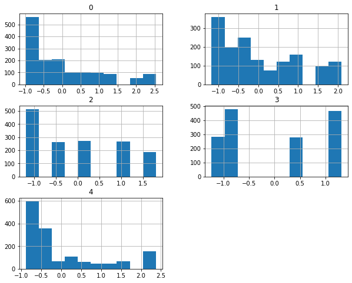

```python
X_ss.hist(figsize=(10,8))
```

```
array([[<matplotlib.axes._subplots.AxesSubplot object at 0x7fde6258a490>,
      dtype=object)
```

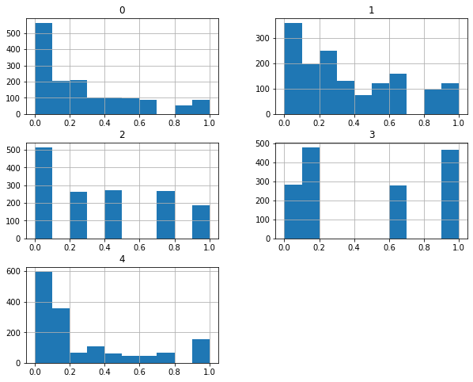

```python
X_mm.hist(figsize=(10,8))
```

Splitting data into different test and train size Case 1 - 20% test and 80% train Case 2 - 90% test and 10% train

```python
from sklearn.model_selection import train_test_split
#Data Scaled with with MinMax Scaler
xm_train1, xm_test1, y_train1, y_test1 = train_test_split(X_mm,Y,test_size=0.2,random_state=42)
xm_train2, xm_test2, y_train2, y_test2 = train_test_split(X_mm,Y,test_size=0.9,random_state=42)
#Data Scaled with Standard Scaler
xs_train1, xs_test1, y_train1, y_test1 = train_test_split(X_ss,Y,test_size=0.2,random_state=42)
xs_train2, xs_test2, y_train2, y_test2 = train_test_split(X_ss,Y,test_size=0.9,random_state=42)
```

```python
#Performance with Standard Scaler
from sklearn.linear_model import LinearRegression
from sklearn import metrics
from sklearn.metrics import accuracy_score,f1_score,recall_score,precision_score
lg = LinearRegression()
rega_ss = lg.fit(xs_train1,y_train1)
regb_ss = lg.fit(xs_train2,y_train2)
as_predict = rega_ss.predict(xs_test1)
bs_predict = regb_ss.predict(xs_test2)
#model 1 performance with Standard Scaler
print(pd.DataFrame({'Actual Value' : y_test1, 'Predicted Value' : as_predict}).head(5))
print ("Accuracy Score for Model-1 with Standard Scaler: ",rega_ss.score(xs_test1, y_test1))
#model 1 performance with Standard Scaler
print(pd.DataFrame({'Actual Value' : y_test2,'Predicted Value' : bs_predict}).head(5))
print ("Accuracy Score for Model 2 with Standard Scaler:: ",regb_ss.score(xs_test2, y_test2))
```

```
      Actual Value  Predicted Value
51         125.045       124.050220
1465       118.767       120.175414
184        120.233       119.785988
1000       137.047       127.858509
746        134.556       128.587480
Accuracy Score for Model-1 with Standard Scaler:  0.5332418618737425
      Actual Value  Predicted Value
51         125.045       124.050220
1465       118.767       120.175414
184        120.233       119.785988
1000       137.047       127.858509
746        134.556       128.587480
Accuracy Score for Model 2 with Standard Scaler::  0.5145995945531906
```

```python
rega_mm = lg.fit(xm_train1,y_train1)
regb_mm = lg.fit(xm_train2,y_train2)
am_predict = rega_mm.predict(xm_test1)
bm_predict = regb_mm.predict(xm_test2)
#model 1 performance with MinMax Scaler
print(pd.DataFrame({'Actual Value' : y_test1, 'Predicted Value' : am_predict}).head(5))
print ("Accuracy Score for Model-1 with MinMax Scaler: ",rega_mm.score(xm_test1, y_test1))
#model 2 performancewith MinMax Scaler
print(pd.DataFrame({'Actual Value' : y_test2, 'Predicted Value' : bm_predict}).head(5))
print ("Accuracy Score for Model-2 with MinMax Scaler:: ",rega_mm.score(xm_test2, y_test2))
```

```
      Actual Value  Predicted Value
51         125.045       124.050220
1465       118.767       120.175414
184        120.233       119.785988
1000       137.047       127.858509
746        134.556       128.587480
Accuracy Score for Model-1 with MinMax Scaler:  0.5332418618737428
      Actual Value  Predicted Value
51         125.045       124.050220
1465       118.767       120.175414
184        120.233       119.785988
1000       137.047       127.858509
746        134.556       128.587480
Accuracy Score for Model-2 with MinMax Scaler::  0.5145995945531909
```

**Performance with Model 1 is slightly better than performance with Model 2 with both MinMaxScaler and StandardScaler.**

**KFold Cross Validation**

```python
from sklearn.model_selection import KFold
from sklearn.model_selection import cross_val_score
# Set the KFold module for 10 splits:

folds = KFold(n_splits = 10, shuffle = True, random_state = 100)
lr = LinearRegression()
```

**KFold Cross Vaidation shows that appropriate selection of Hyper Parameters can provide score of .62.**

```python
#scores of KFold Cross Validation
scores_mm = cross_val_score(lr, X_mm, Y, scoring='r2', cv=folds)
print('score with MixMax- ',scores_mm)
scores_cv = pd.DataFrame({
    'KFold CV Min Score (MinMaxScaler)': [min(scores_mm)],
    'KFold CV Max Score (MinMaxScaler)': [max(scores_mm)],
    })

scores_cv
```

```
score with MixMax-  [0.56132035 0.50340473 0.4997205  0.57088213 0.39378636 0.52924493
 0.40000788 0.52055302 0.62281764 0.52383812]
```

|  | KFold CV Min Score (MinMaxScaler) | KFold CV Max Score (MinMaxScaler) |
| --- | --- | --- |
| 0 | 0.393786 | 0.622818 |

```python
%%shell
jupyter nbconvert --to html /content/Group107_Airfoil_Self_noise.ipynb
```

```
[NbConvertApp] Converting notebook /content/Group107_Airfoil_Self_noise.ipynb to html
[NbConvertApp] Writing 803303 bytes to /content/Group107_Airfoil_Self_noise.html
```